# DATS6101 Project 2: Exploring Hotel Booking Cancellations

Group 6 : Jasreen Kaur Mehta, Pranav Dhawan, Tycho Gormley

2024-12-09

# **Part 1 Recap**

## **Introduction**

In our Part 1, we analyzed a hotel booking dataset from the INN Hotels Group to understand the factors influencing booking cancellations.

```r
hotel_data <- read.csv("../../Dataset/INNHotelsGroup_min.csv")
hotel_datay <- read.csv("../../Dataset/INNHotelsGroup.csv")
```

```r
str(hotel_datay)
```

```
## 'data.frame':    36275 obs. of  19 variables:
##  $ Booking_ID                          : chr  "INN00001" "INN00002" "INN00003" "INN00004" ...
##  $ no_of_adults                        : int  2 2 1 2 2 2 2 2 3 2 ...
##  $ no_of_children                      : int  0 0 0 0 0 0 0 0 0 0 ...
##  $ no_of_weekend_nights                : int  1 2 2 0 1 0 1 1 0 0 ...
##  $ no_of_week_nights                   : int  2 3 1 2 1 2 3 3 4 5 ...
##  $ type_of_meal_plan                   : chr  "Meal Plan 1" "Not Selected" "Meal Plan 1" "Meal Plan 1" ...
##  $ required_car_parking_space          : int  0 0 0 0 0 0 0 0 0 0 ...
##  $ room_type_reserved                  : chr  "Room_Type 1" "Room_Type 1" "Room_Type 1" "Room_Type 1" ...
##  $ lead_time                           : int  224 5 1 211 48 346 34 83 121 44 ...
##  $ arrival_year                        : int  2017 2018 2018 2018 2018 2018 2017 2018 2018 2018 ...
##  $ arrival_month                       : int  10 11 2 5 4 9 10 12 7 10 ...
##  $ arrival_date                        : int  2 6 28 20 11 13 15 26 6 18 ...
##  $ market_segment_type                 : chr  "Offline" "Online" "Online" "Online" ...
##  $ repeated_guest                      : int  0 0 0 0 0 0 0 0 0 0 ...
##  $ no_of_previous_cancellations        : int  0 0 0 0 0 0 0 0 0 0 ...
##  $ no_of_previous_bookings_not_canceled: int  0 0 0 0 0 0 0 0 0 0 ...
##  $ avg_price_per_room                  : num  65 106.7 60 100 94.5 ...
##  $ no_of_special_requests              : int  0 1 0 0 0 1 1 1 1 3 ...
##  $ booking_status                      : chr  "Not_Canceled" "Not_Canceled" "Canceled" "Canceled" ...
```

The dataset contains hotel bookings collected from 2017-2018 and is characterized by a total of 19 columns, comprising 5 categorical and 14 numerical variables.

## **Exploratory Data Analysis (EDA)**

### **1. Summary Statistics**

```r
summary(hotel_data)
```

```
##   no_of_adults  no_of_children  no_of_weekend_nights no_of_week_nights
##  Min.   :0.00   Min.   : 0.00   Min.   :0.00         Min.   : 0.0
##  1st Qu.:2.00   1st Qu.: 0.00   1st Qu.:0.00         1st Qu.: 1.0
##  Median :2.00   Median : 0.00   Median :1.00         Median : 2.0
##  Mean   :1.84   Mean   : 0.11   Mean   :0.81         Mean   : 2.2
##  3rd Qu.:2.00   3rd Qu.: 0.00   3rd Qu.:2.00         3rd Qu.: 3.0
##  Max.   :4.00   Max.   :10.00   Max.   :7.00         Max.   :17.0
##  type_of_meal_plan  required_car_parking_space room_type_reserved   lead_time
##  Length:36275       Min.   :0.000              Length:36275       Min.   :  0
##  Class :character   1st Qu.:0.000              Class :character   1st Qu.: 17
##  Mode  :character   Median :0.000              Mode  :character   Median : 57
##                     Mean   :0.031                                 Mean   : 85
##                     3rd Qu.:0.000                                 3rd Qu.:126
##                     Max.   :1.000                                 Max.   :443
##   arrival_year  arrival_month   market_segment_type repeated_guest
##  Min.   :2017   Min.   : 1.00   Length:36275        Min.   :0.000
##  1st Qu.:2018   1st Qu.: 5.00   Class :character    1st Qu.:0.000
##  Median :2018   Median : 8.00   Mode  :character    Median :0.000
##  Mean   :2018   Mean   : 7.42                       Mean   :0.026
##  3rd Qu.:2018   3rd Qu.:10.00                       3rd Qu.:0.000
##  Max.   :2018   Max.   :12.00                       Max.   :1.000
##  no_of_previous_cancellations no_of_special_requests booking_status
##  Min.   : 0.00                Min.   :0.00           Length:36275
##  1st Qu.: 0.00                1st Qu.:0.00           Class :character
##  Median : 0.00                Median :0.00           Mode  :character
##  Mean   : 0.02                Mean   :0.62
##  3rd Qu.: 0.00                3rd Qu.:1.00
##  Max.   :13.00                Max.   :5.00
##  avg_price_per_room
##  Min.   :  0
##  1st Qu.: 80
##  Median : 99
##  Mean   :103
##  3rd Qu.:120
##  Max.   :540
```

### **2. Distribution of Booking Status**

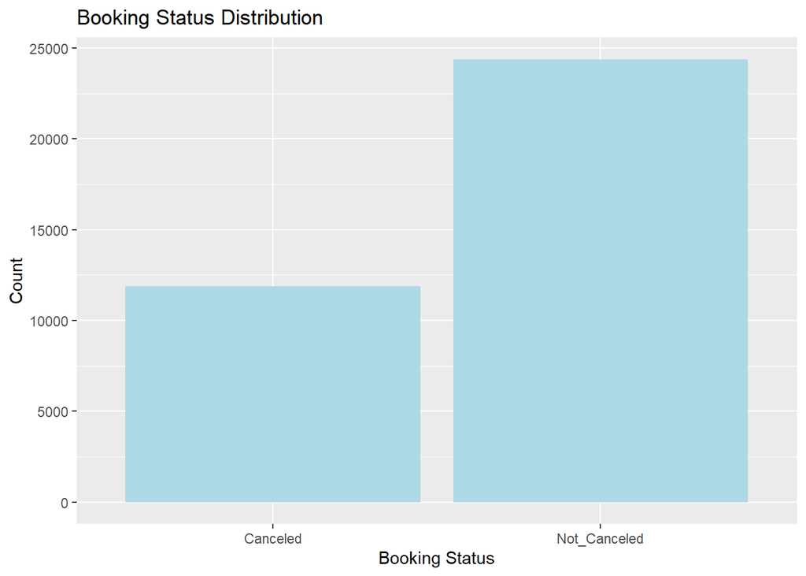

```r
print(ggplot(hotel_data, aes(x = booking_status)) +
  geom_bar(fill = "lightblue") +
  labs(title = "Booking Status Distribution", x = "Booking Status", y = "Count"))
```

**Summary**  
The dataset contains 36,275 bookings. Of the total bookings, 24,390 bookings were not canceled (67.2%), while 11,885 bookings were canceled (32.8%), reflecting a significant cancellation rate that offers rich insights into factors influencing booking decisions.

### **3. Barplot: Number of Special Requests**

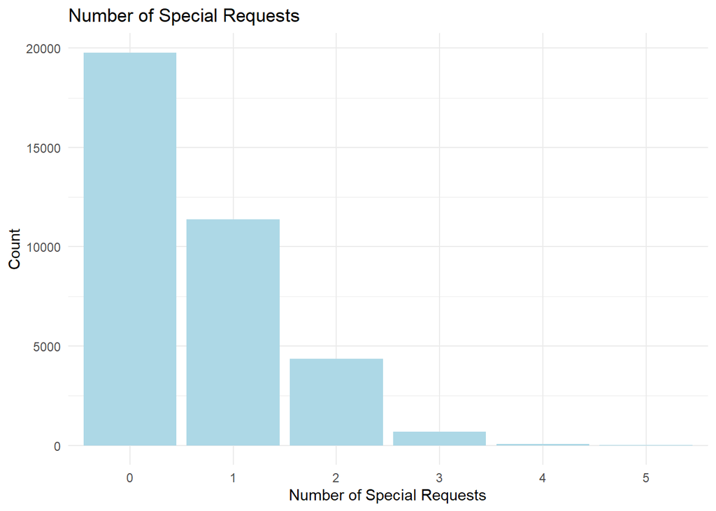

```r
print(ggplot(hotel_data, aes(x = factor(no_of_special_requests))) +
  geom_bar(fill = "lightblue") +
  labs(title = "Number of Special Requests", x = "Number of Special Requests", y = "Count") +
  theme_minimal())
```

**Summary**  
Most guests make no special requests, with a sharp decline as the number increases. A significant portion makes one request, while two or more requests are increasingly rare.

### **4. Plot: Market Segment vs Booking Status**

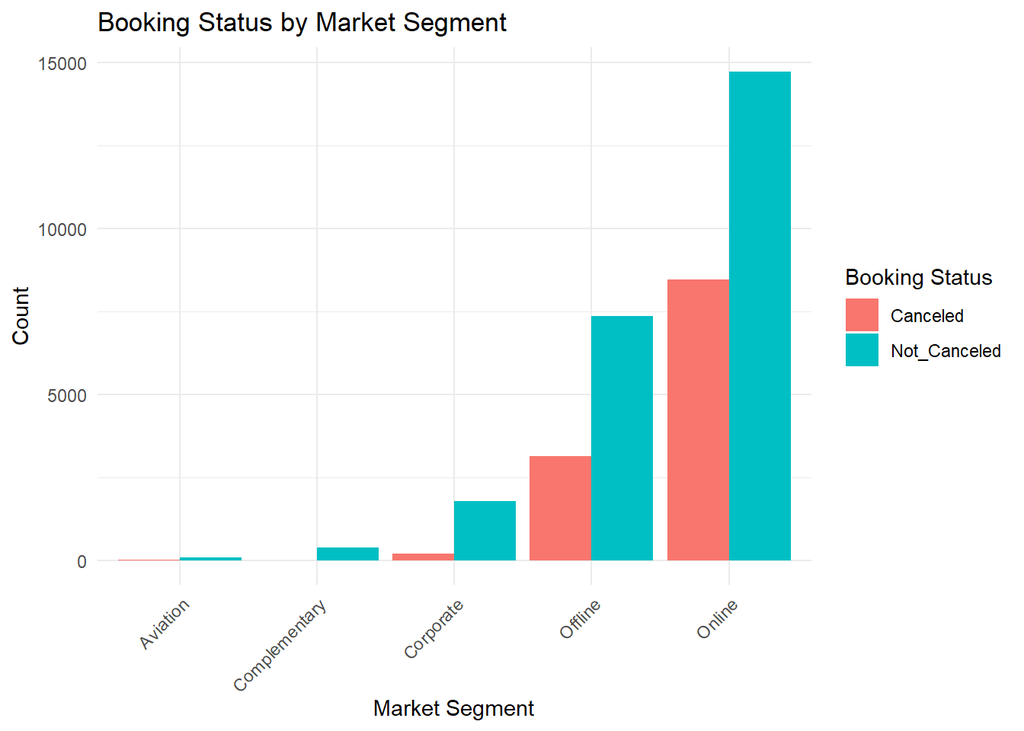

```r
contingency_table <- table(hotel_data$market_segment_type, hotel_data$booking_status)

plot_data <- as.data.frame(contingency_table)
colnames(plot_data) <- c("Market_Segment", "Booking_Status", "Count")

print(ggplot(plot_data, aes(x = Market_Segment, y = Count, fill = Booking_Status)) +
  geom_bar(stat = "identity", position = "dodge") +
  theme_minimal() +
  labs(title = "Booking Status by Market Segment",
       x = "Market Segment",
       y = "Count",
       fill = "Booking Status") +
  theme(axis.text.x = element_text(angle = 45, hjust = 1)))
```

### **5. Histogram: Lead_time**

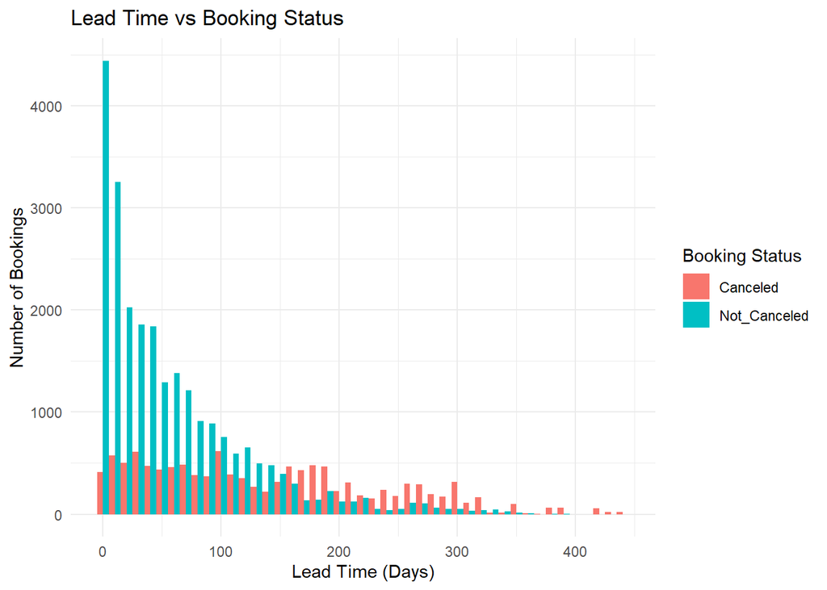

```r
ggplot(hotel_data, aes(x = lead_time, fill = booking_status)) +
  geom_histogram(binwidth = 10, position = "dodge") +
  labs(
    title = "Lead Time vs Booking Status",
    x = "Lead Time (Days)",
    y = "Number of Bookings",
    fill = "Booking Status"
  ) +
  theme_minimal()
```

**Summary**  
Here we can see that the booking with short lead times are less cancelled and as the lead time increases there are more booking cancellations. Also, we can see more cancellation happening between lead time form 100-200.

### **6. Boxplot: avg_price_per_room**

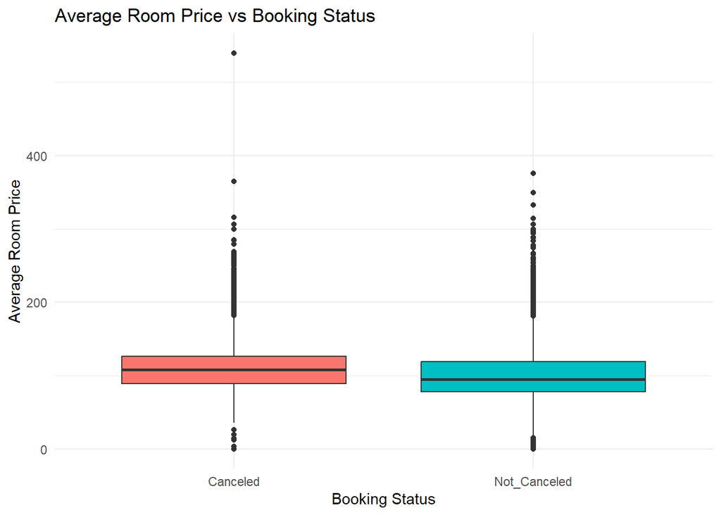

```r
ggplot(hotel_data, aes(x = booking_status, y = avg_price_per_room, fill = booking_status)) +
  geom_boxplot() +
  labs(
    title = "Average Room Price vs Booking Status",
    x = "Booking Status",
    y = "Average Room Price"
  ) +
  theme_minimal() +
  theme(legend.position = "none")
```

**Summary**  
The booking with cancelled status has higher median average room price value compared to non-cancelled booking status.This might mean that the booking with her average room price have more chances to get cancelled.

## **Key Statistical Findings**

**1. Special Requests and Cancellations:**  
Bookings with special requests had a significantly lower cancellation rate (20.2%) compared to those without (43.2%). Chi-square test revealed a statistically significant association between special requests and booking status.

**2. Previous Cancellation History:**  
Surprisingly, guests with previous cancellations had a much lower current cancellation rate (4.73%) compared to those without (33.03%).  
This suggests that past cancellation history might not be a straightforward predictor of future booking behavior.

**3. Factors Influencing Cancellations:**  
**3.1 Lead Time:**

1. Average lead time for canceled bookings: 139.2 days
2. Average lead time for non-canceled bookings: 58.9 days
3. Longer lead times strongly correlated with higher cancellation probability.

**3.2 Room Price:**

1. Canceled bookings had a higher average room price.
2. Price difference: Approximately 10.7 units higher for canceled bookings.

**4. Seasonal Variations:**  
The correlation between factors and cancellations varied across seasons:

**4.1 Fall:**  
Strongest lead time correlation (0.54).

**4.2 Summer:**  
Special requests most negatively correlated with cancellations (-0.30).

**4.3 Spring:**  
Unique pattern with special requests having a strong negative correlation (-0.36).

**4.4 Winter:**  
Slightly different dynamics with weaker correlations.

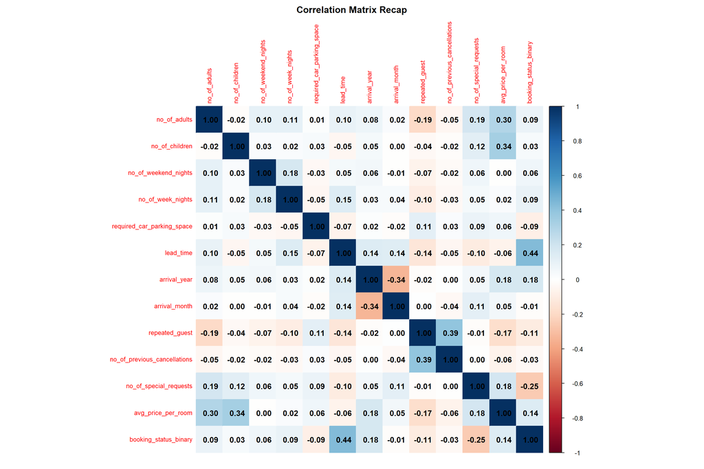

```r
hotel_data$booking_status_binary <- ifelse(hotel_data$booking_status == "Canceled", 1, 0)

remove_zero_variance <- function(df) {
  df[, sapply(df, function(col) sd(col, na.rm = TRUE) != 0)]
}

data_filtered <- remove_zero_variance(select_if(hotel_data, is.numeric))

cor_data <- cor(data_filtered, use = "complete.obs")

corrplot(cor_data, method = "color", addCoef.col = "black",
         title = "Correlation Matrix Recap", number.cex = 1,
         tl.cex = 0.8, mar = c(1, 1, 2, 1))
```

Lead time strongly predicts cancellations, with longer lead times increasing likelihood (0.44). More special requests (-0.25) and repeated guest status (-0.11) reduce cancellations, reflecting customer commitment and loyalty. Price per room has a weak positive correlation (0.14) with cancellations. Factors like travel party size and stay length show minimal impact on cancellation likelihood.

## **Preliminary Conclusions:**

**1.** Lead time emerged as the most critical factor in predicting booking cancellations.  
**2.** Special requests significantly reduce the likelihood of cancellations.  
**3.** Booking behavior varies considerably across different seasons.  
**4.** Higher-priced rooms show a slight tendency towards more cancellations.

# **SMART Questions:**

## **1. Can we predict the likelihood of booking cancellation based on the lead time?**

Given that lead time demonstrated the strongest correlation with booking status, we initially selected lead time as our primary predictor variable and booking status as our target variable to begin our analysis.

```r
set.seed(123)
train_index <- createDataPartition(hotel_data$booking_status_binary, p = 0.7, list = FALSE)
train_data <- hotel_data[train_index, ]
test_data <- hotel_data[-train_index, ]
```

```r
logistic_model <- glm(
  booking_status_binary ~ lead_time,
  data = train_data,
  family = binomial()
)

summary(logistic_model)
```

```
##
## Call:
## glm(formula = booking_status_binary ~ lead_time, family = binomial(),
##     data = train_data)
##
## Coefficients:
##             Estimate Std. Error z value Pr(>|z|)
## (Intercept) -1.82038    0.02328   -78.2   <2e-16 ***
## lead_time    0.01180    0.00019    62.1   <2e-16 ***
## ---
## Signif. codes:  0 '***' 0.001 '**' 0.01 '*' 0.05 '.' 0.1 ' ' 1
##
## (Dispersion parameter for binomial family taken to be 1)
##
##     Null deviance: 32083  on 25392  degrees of freedom
## Residual deviance: 27091  on 25391  degrees of freedom
## AIC: 27095
##
## Number of Fisher Scoring iterations: 4
```

The analysis reveals a significant positive relationship between lead time and booking cancellation probability. As the lead time increases, the log-odds of a booking being canceled also increase, with a coefficient of 0.01180. This suggests that bookings made further in advance are more likely to be canceled. Both the intercept and lead time coefficient are statistically highly significant (p-value < 0.001), indicating that lead time is a reliable and strong predictor of cancellation risk.

```r
test_predictions <- predict(logistic_model, newdata = test_data, type = "response")
predicted_classes <- ifelse(test_predictions > 0.5, 1, 0)
```

```r
confusion_matrix <- table(Actual = test_data$booking_status_binary,
                          Predicted = predicted_classes)
print("Confusion Matrix:")
```

```
## [1] "Confusion Matrix:"
```

```r
print(confusion_matrix)
```

```
##       Predicted
## Actual    0    1
##      0 6720  570
##      1 2102 1490
```

```r
accuracy <- sum(diag(confusion_matrix)) / sum(confusion_matrix)
precision <- confusion_matrix[2,2] / sum(confusion_matrix[,2])
recall <- confusion_matrix[2,2] / sum(confusion_matrix[2,])
f1_score <- 2 * (precision * recall) / (precision + recall)

cat("\nModel Performance Metrics:\nAccuracy:", round(accuracy, 4), "\nPrecision:", round(precision, 4), "\nRecall:", round(recall, 4), "\nF1 Score:", round(f1_score, 4), "\n")
```

```
##
## Model Performance Metrics:
## Accuracy: 0.754
## Precision: 0.723
## Recall: 0.415
## F1 Score: 0.527
```

**1. Accuracy:** 0.754, meaning the model correctly classifies 75.4% of the bookings.  
**2. Precision:** 0.723, indicating that 72.3% of the predictions of canceled bookings are correct.  
**3. Recall:** 0.415, meaning the model correctly identifies 41.5% of the actual canceled bookings.  
**4. F1-Score:** 0.527, which is the harmonic mean of precision and recall, providing a balanced evaluation of the model’s performance.

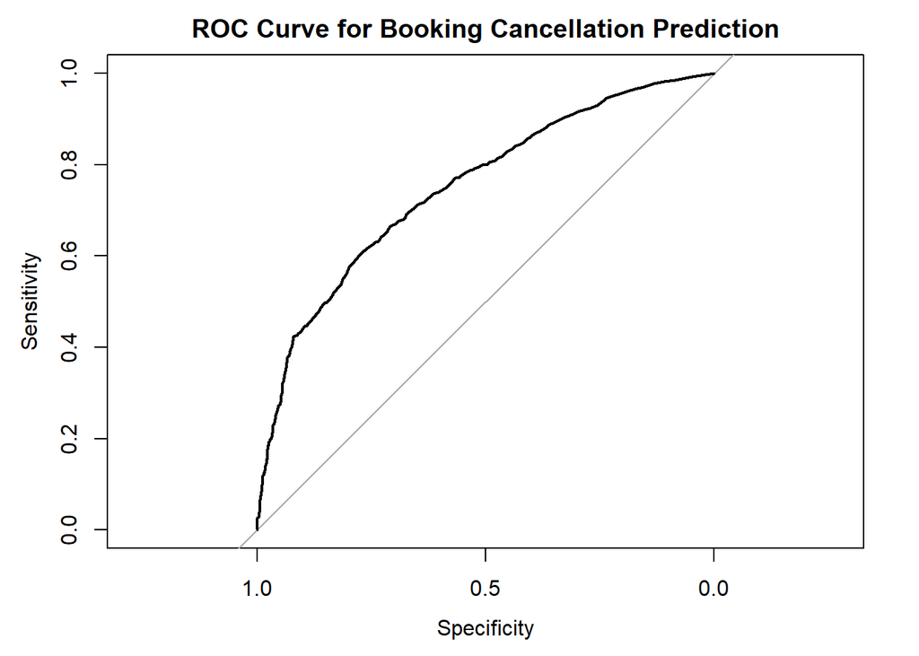

```r
roc_curve <- roc(test_data$booking_status_binary, test_predictions)
plot(roc_curve, main = "ROC Curve for Booking Cancellation Prediction")
```

```r
auc_value <- auc(roc_curve)
cat("Area Under the ROC Curve (AUC):", round(auc_value, 4), "\n")
```

```
## Area Under the ROC Curve (AUC): 0.75
```

Area Under the ROC Curve (AUC): 0.75, suggesting the model has good discriminative power in predicting booking cancellations.

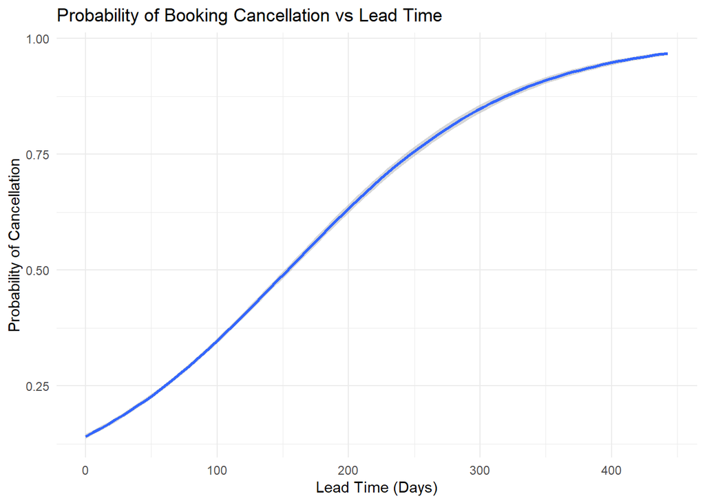

```r
hotel_data$booking_status_binary <- as.numeric(as.character(hotel_data$booking_status_binary))

ggplot(hotel_data, aes(x = lead_time, y = booking_status_binary)) +
  geom_smooth(method = "glm", method.args = list(family = "binomial"), se = TRUE) +
  labs(
    title = "Probability of Booking Cancellation vs Lead Time",
    x = "Lead Time (Days)",
    y = "Probability of Cancellation"
  ) +
  theme_minimal()
```

## **2. Can we predict high-demand periods?**

We created a high-demand column by taking the average price per room and identifying bookings in the top 25% of prices. In our random forest model, we used features like lead time, total nights, booking month, market segment, and repeated guest status to predict these high-demand bookings.

```r
prepare_booking_data <- function(hotel_data) {
  booking_data <- hotel_data %>%
    mutate(
      high_demand = as.factor(ifelse(
        avg_price_per_room > quantile(avg_price_per_room, 0.75),
        1, 0
      )),
      booking_month = as.factor(arrival_month),
      is_weekend = no_of_weekend_nights > 0,
      total_nights = no_of_weekend_nights + no_of_week_nights,
      is_repeated_guest = repeated_guest > 0
    )

  return(booking_data)
}
prepared_data <- prepare_booking_data(hotel_data)
```

```r
set.seed(123)
train_index <- createDataPartition(prepared_data$high_demand, p = 0.7, list = FALSE)
train_data <- prepared_data[train_index, ]
test_data <- prepared_data[-train_index, ]
```

```r
# Random Forest Model
rf_model <- randomForest(
  high_demand ~ lead_time +
                total_nights +
                booking_month +
                market_segment_type +
                is_repeated_guest,
  data = train_data,
  ntree = 500,
  importance = TRUE
)

evaluate_model <- function(actual, predicted, model_name) {
  conf_matrix <- confusionMatrix(as.factor(predicted), as.factor(actual))

  results <- data.frame(
    Model = model_name,
    Accuracy = conf_matrix$overall['Accuracy'],
    Precision = conf_matrix$byClass['Precision'],
    Recall = conf_matrix$byClass['Recall'],
    F1 = conf_matrix$byClass['F1']
  )

  return(results)
}

rf_pred <- predict(rf_model, newdata = test_data, type = "prob")[,2]
rf_class <- ifelse(rf_pred > 0.5, 1, 0)
```

```r
rf_results <- evaluate_model(test_data$high_demand, rf_class, "Random Forest")
print(rf_results)
```

```
##                  Model Accuracy Precision Recall    F1
## Accuracy Random Forest     0.81     0.847  0.912 0.878
```

```r
rf_importance <- data.frame(
  Feature = rownames(importance(rf_model)),
  Importance = importance(rf_model)[,1]
) %>% arrange(desc(Importance))
print(head(rf_importance, 10))
```

```
##                                 Feature Importance
## booking_month             booking_month      100.9
## lead_time                     lead_time       92.9
## market_segment_type market_segment_type       85.6
## total_nights               total_nights       50.4
## is_repeated_guest     is_repeated_guest       12.9
```

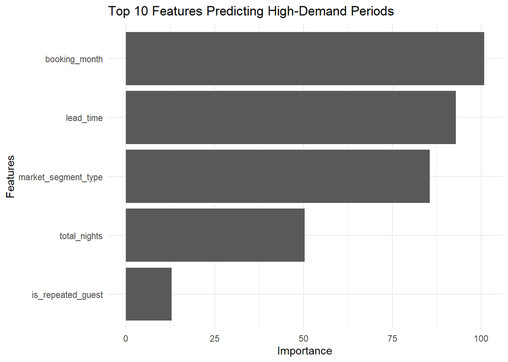

```r
ggplot(head(rf_importance, 10), aes(x = reorder(Feature, Importance), y = Importance)) +
  geom_bar(stat = "identity") +
  coord_flip() +
  labs(
    title = "Top 10 Features Predicting High-Demand Periods",
    x = "Features",
    y = "Importance"
  ) +
  theme_minimal()
```

Feature importance revealed that booking month emerged as the most critical predictor, followed closely by lead time and market segment. This suggests that when a booking is made, its timing and market segment are strong indicators of whether it will be a high-value reservation.

```r
predict_high_demand_periods <- function(model, test_data) {
  pred_probs <- predict(model, newdata = test_data, type = "prob")[,2]
  high_demand_periods <- test_data[pred_probs > 0.7, ]

  print("High-Demand Periods Prediction:")
  print(paste("Total High-Demand Periods:", sum(pred_probs > 0.7)))
  print("Sample of High-Demand Periods:")
  print(head(high_demand_periods))

  return(high_demand_periods)
}

high_demand_periods <- predict_high_demand_periods(rf_model, test_data)
```

```
## [1] "High-Demand Periods Prediction:"
## [1] "Total High-Demand Periods: 1462"
## [1] "Sample of High-Demand Periods:"
##     no_of_adults no_of_children no_of_weekend_nights no_of_week_nights
## 62             1              0                    0                 3
## 110            2              0                    2                 1
## 181            2              0                    0                 3
## 202            2              0                    0                 2
## 223            2              0                    1                 5
## 232            2              1                    1                 3
##     type_of_meal_plan required_car_parking_space room_type_reserved lead_time
## 62        Meal Plan 1                          0        Room_Type 4        19
## 110       Meal Plan 1                          0        Room_Type 1        32
## 181       Meal Plan 1                          0        Room_Type 1        11
## 202       Meal Plan 1                          0        Room_Type 1        80
```

[output cut: 30 more lines]

This function use the random forest model to predict probabilities for high-demand bookings in the test data and it identifies high-demand periods by filtering for predictions with a probability greater than 0.7.

## **3. What is the relationship between room price and the likelihood of a booking being canceled or not?**

```r
# Fit a logistic regression model
lrmodel1 <- glm(booking_status_binary ~ avg_price_per_room, data = hotel_data, family = binomial)

summary(lrmodel1)
```

```
##
## Call:
## glm(formula = booking_status_binary ~ avg_price_per_room, family = binomial,
##     data = hotel_data)
##
## Coefficients:
##                     Estimate Std. Error z value Pr(>|z|)
## (Intercept)        -1.632519   0.036523   -44.7   <2e-16 ***
## avg_price_per_room  0.008695   0.000326    26.7   <2e-16 ***
## ---
## Signif. codes:  0 '***' 0.001 '**' 0.01 '*' 0.05 '.' 0.1 ' ' 1
##
## (Dispersion parameter for binomial family taken to be 1)
##
##     Null deviance: 45887  on 36274  degrees of freedom
## Residual deviance: 45153  on 36273  degrees of freedom
## AIC: 45157
##
## Number of Fisher Scoring iterations: 4
```

```r
hotel_data$predicted_prob <- predict(lrmodel1, type = "response")

hotel_data$predicted_class <- ifelse(hotel_data$predicted_prob > 0.5, 1, 0)

# Model evaluation
conf_matrix <- table(hotel_data$booking_status_binary, hotel_data$predicted_class)
accuracy <- sum(diag(conf_matrix)) / sum(conf_matrix)
print(paste("Accuracy:", round(accuracy, 2)))
```

```
## [1] "Accuracy: 0.67"
```

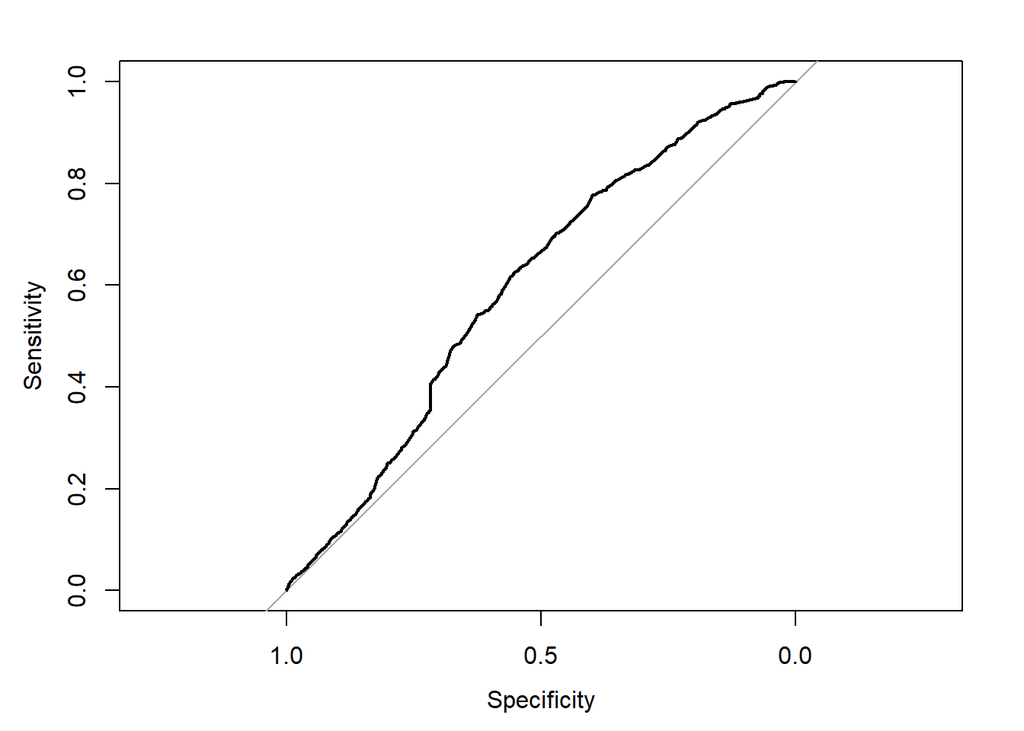

```r
roc_curve <- roc(hotel_data$booking_status_binary, hotel_data$predicted_prob)
plot(roc_curve)
```

```r
auc_value <- auc(roc_curve)
print(paste("AUC:", round(auc_value, 2)))
```

```
## [1] "AUC: 0.6"
```

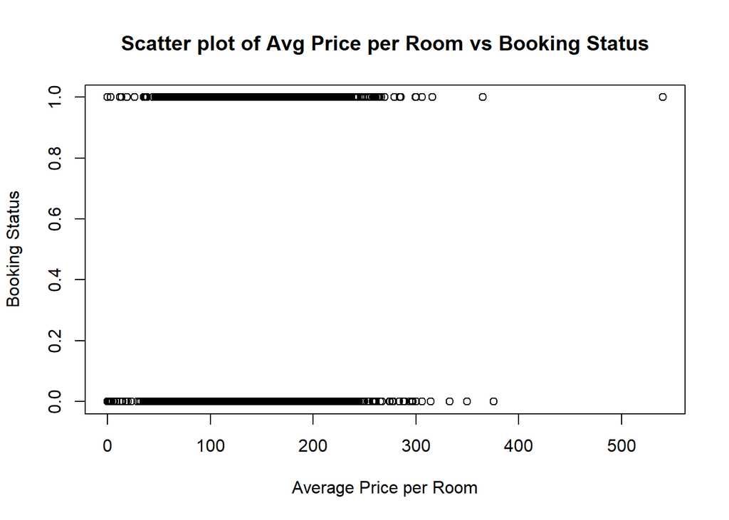

```r
# Scatter plot to examine the relationship between price and cancellation
plot(hotel_data$avg_price_per_room, hotel_data$booking_status_binary,
     main = "Scatter plot of Avg Price per Room vs Booking Status",
     xlab = "Average Price per Room", ylab = "Booking Status")
```

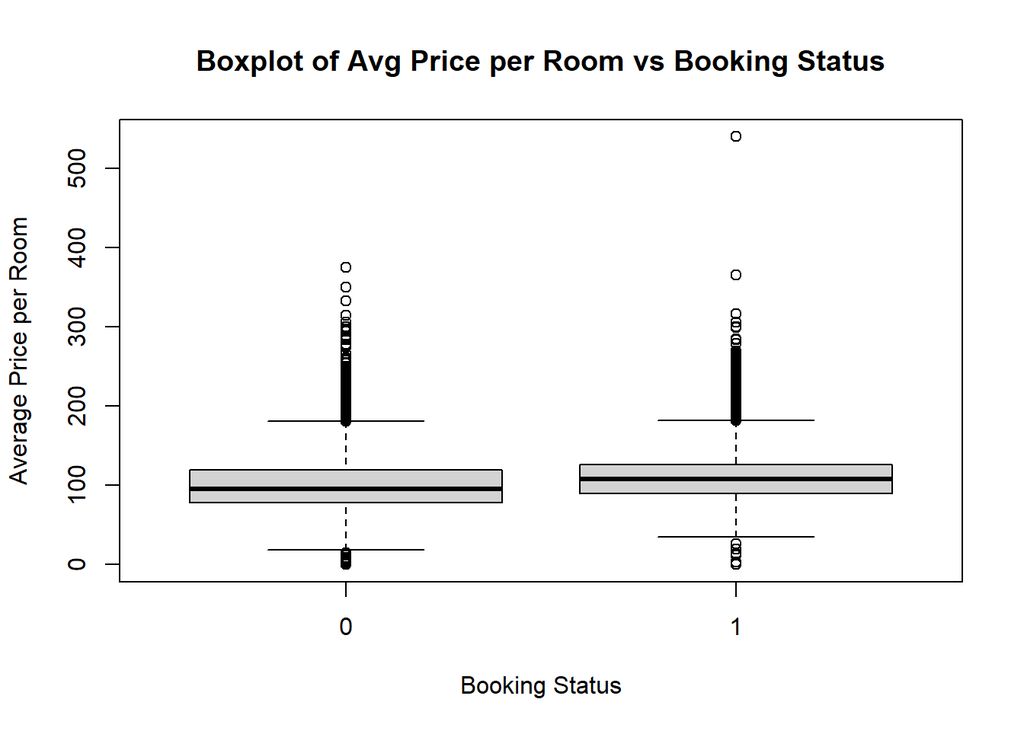

```r
# Boxplot for average price per room vs booking cancellation status
boxplot(avg_price_per_room ~ booking_status_binary, data = hotel_data,
        main = "Boxplot of Avg Price per Room vs Booking Status",
        xlab = "Booking Status", ylab = "Average Price per Room")
```

## **4. How do seasonal trends impact cancellation rates and booking patterns?**

### **Define seasons based on arrival month:**

```r
hotel_data$season <- case_when(
  hotel_data$arrival_month %in% c(3, 4, 5) ~ "Spring",
  hotel_data$arrival_month %in% c(6, 7, 8) ~ "Summer",
  hotel_data$arrival_month %in% c(9, 10, 11) ~ "Fall",
  hotel_data$arrival_month %in% c(12, 1, 2) ~ "Winter",
  TRUE ~ "Unknown"
)
```

### **Creating subsets for each season:**

```r
# Create subsets for each season
spring_data <- subset(hotel_data, season == "Spring")
summer_data <- subset(hotel_data, season == "Summer")
fall_data <- subset(hotel_data, season == "Fall")
winter_data <- subset(hotel_data, season == "Winter")
```

### **Remove columns with zero variance:**

```r
# Function to remove columns with zero variance
remove_zero_variance <- function(df) {
  df[, sapply(df, function(col) sd(col, na.rm = TRUE) != 0)]
}

# Remove zero variance columns for each season
spring_data_filtered <- remove_zero_variance(select_if(spring_data, is.numeric))
summer_data_filtered <- remove_zero_variance(select_if(summer_data, is.numeric))
fall_data_filtered <- remove_zero_variance(select_if(fall_data, is.numeric))
winter_data_filtered <- remove_zero_variance(select_if(winter_data, is.numeric))
```

### **Calculate correlation matrices:**

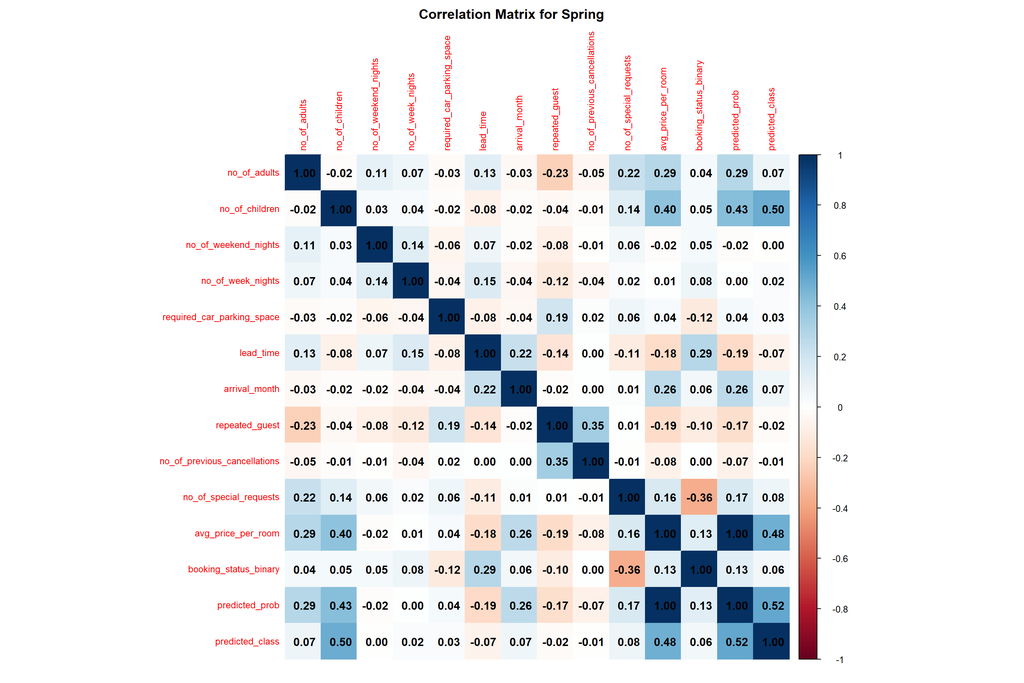

```r
# Calculate and visualize correlation for Spring
cor_spring <- cor(spring_data_filtered, use = "complete.obs")
corrplot(cor_spring, method = "color", addCoef.col = "black",
         title = "Correlation Matrix for Spring", number.cex = 1,
         tl.cex = 0.8, mar = c(1, 1, 2, 1))
```

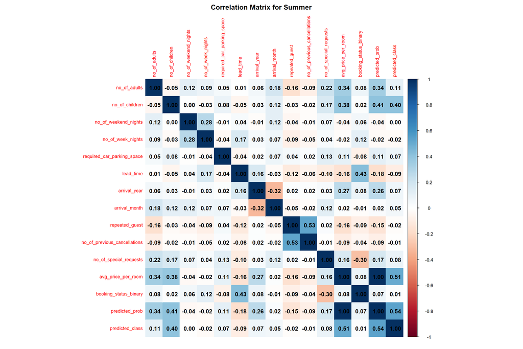

```r
# Calculate and visualize correlation for Summer
cor_summer <- cor(summer_data_filtered, use = "complete.obs")
corrplot(cor_summer, method = "color", addCoef.col = "black",
         title = "Correlation Matrix for Summer", number.cex = 1,
         tl.cex = 0.8, mar = c(1, 1, 2, 1))
```

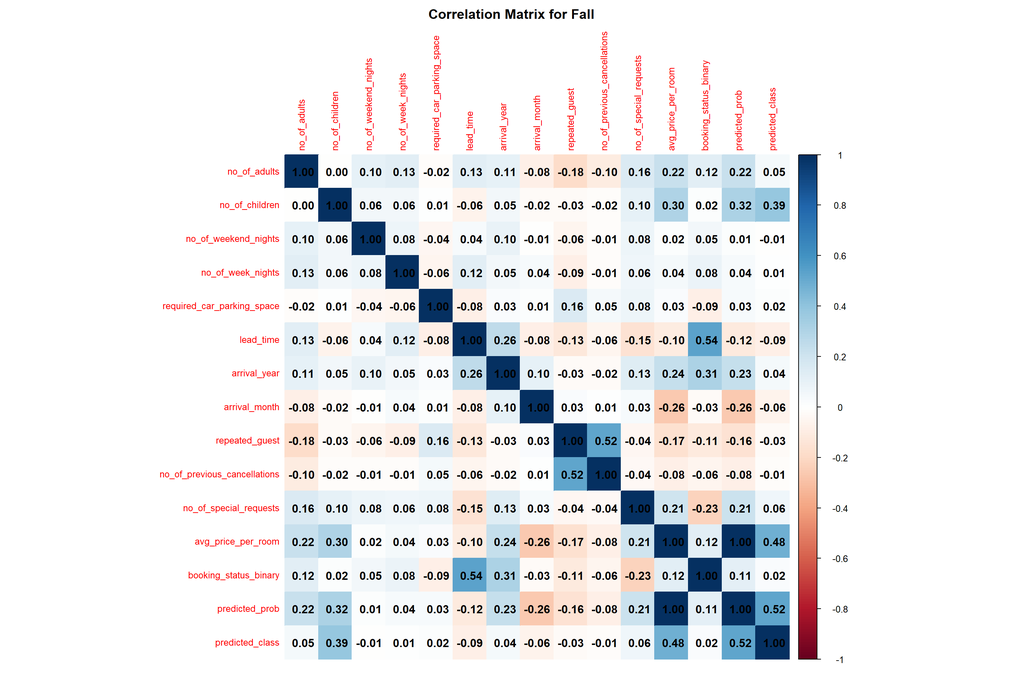

```r
# Calculate and visualize correlation for Fall
cor_fall <- cor(fall_data_filtered, use = "complete.obs")
corrplot(cor_fall, method = "color", addCoef.col = "black",
         title = "Correlation Matrix for Fall", number.cex = 1,
         tl.cex = 0.8, mar = c(1, 1, 2, 1))
```

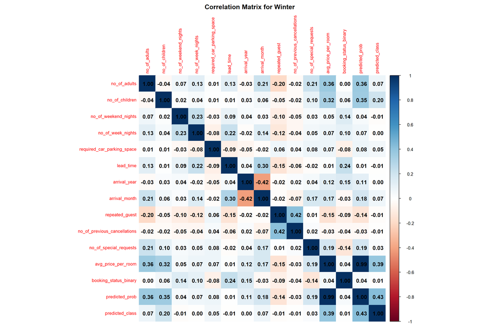

```r
# Calculate and visualize correlation for Winter
cor_winter <- cor(winter_data_filtered, use = "complete.obs")
corrplot(cor_winter, method = "color", addCoef.col = "black",
         title = "Correlation Matrix for Winter", number.cex = 1,
         tl.cex = 0.8, mar = c(1, 1, 2, 1))
```

### Logistic Regression: Impact of Seasonality on Booking Status

```r
### Logistic Regression: Impact of Seasonality on Booking Status
# Fit logistic regression model
logit_model <- glm(booking_status_binary ~ season, family = binomial, data = hotel_data)

# Summarize the logistic regression model
summary(logit_model)
```

```
##
## Call:
## glm(formula = booking_status_binary ~ season, family = binomial,
##     data = hotel_data)
##
## Coefficients:
##              Estimate Std. Error z value Pr(>|z|)
## (Intercept)   -0.6965     0.0187  -37.28   <2e-16 ***
## seasonSpring   0.0492     0.0304    1.62     0.11
## seasonSummer   0.3406     0.0276   12.32   <2e-16 ***
## seasonWinter  -1.0447     0.0415  -25.18   <2e-16 ***
## ---
## Signif. codes:  0 '***' 0.001 '**' 0.01 '*' 0.05 '.' 0.1 ' ' 1
##
## (Dispersion parameter for binomial family taken to be 1)
##
##     Null deviance: 45887  on 36274  degrees of freedom
## Residual deviance: 44616  on 36271  degrees of freedom
## AIC: 44624
##
## Number of Fisher Scoring iterations: 4
```

```r
# Calculate odds ratios for the season coefficients
odds_ratios <- exp(coef(logit_model))
print(odds_ratios)
```

```
##  (Intercept) seasonSpring seasonSummer seasonWinter
##        0.498        1.050        1.406        0.352
```

```r
# Predict probabilities using the logistic regression model
hotel_data$predicted_probs <- predict(logit_model, type = "response")

# Classify predictions using a 0.5 cutoff
hotel_data$predicted_class <- ifelse(hotel_data$predicted_probs >= 0.5, 1, 0)

# Confusion matrix
confusion_matrix <- table(Predicted = hotel_data$predicted_class, Actual = hotel_data$booking_status_binary)
print(confusion_matrix)
```

```
##          Actual
## Predicted     0     1
##         0 24390 11885
```

```r
# Calculate accuracy
accuracy <- sum(diag(confusion_matrix)) / sum(confusion_matrix)
cat("Accuracy:", accuracy, "\n")
```

```
## Accuracy: 0.672
```

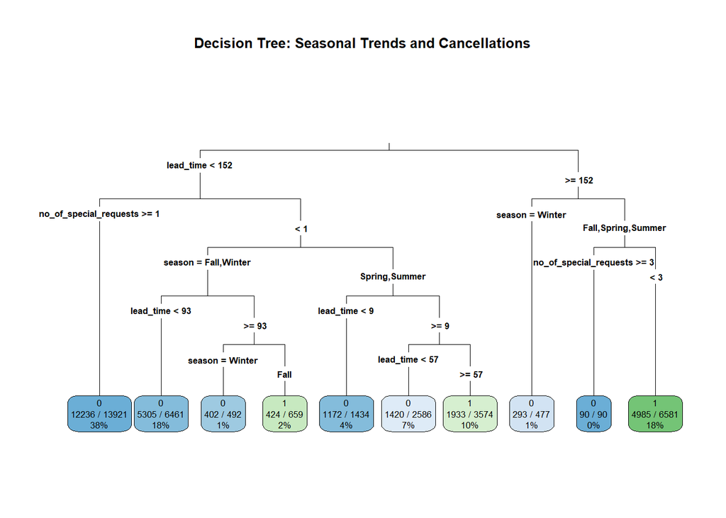

```r
# Fit a decision tree with adjusted parameters
tree_model <- rpart(
  booking_status_binary ~ season + lead_time + no_of_special_requests,
  data = hotel_data,
  method = "class",
  control = rpart.control(cp = 0.001, minsplit = 10, maxdepth = 5)  # Lower cp and minsplit to allow more splits
)

# Plot the updated decision tree
rpart.plot(tree_model, type = 3, extra = 102, fallen.leaves = TRUE,
           main = "Decision Tree: Seasonal Trends and Cancellations")
```

## **5. What key factors most strongly influence booking cancellations?**

```r
hotel_data$type_of_meal_plan <- as.factor(hotel_data$type_of_meal_plan)
hotel_data$room_type_reserved <- as.factor(hotel_data$room_type_reserved)
hotel_data$market_segment_type <- as.factor(hotel_data$market_segment_type)
hotel_data$arrival_month <- as.factor(hotel_data$arrival_month)
```

```r
rf_model1 <-randomForest(booking_status_binary ~ no_of_adults + no_of_children + no_of_weekend_nights +
                          no_of_week_nights + type_of_meal_plan + required_car_parking_space +
                          room_type_reserved + lead_time + arrival_year + arrival_month +
                          market_segment_type + repeated_guest +
                          no_of_previous_cancellations + avg_price_per_room + no_of_special_requests,
                        data = hotel_data, importance = TRUE, ntree = 100)

feature_importance <- importance(rf_model1)

importance_df <- data.frame(Feature = rownames(feature_importance), Importance = feature_importance[,1])

importance_df <- importance_df[order(-importance_df$Importance),]
importance_df
```

```
##                                                   Feature Importance
## lead_time                                       lead_time     221.20
## no_of_special_requests             no_of_special_requests     164.70
## arrival_month                               arrival_month     102.40
## avg_price_per_room                     avg_price_per_room     102.10
## market_segment_type                   market_segment_type      93.08
## no_of_weekend_nights                 no_of_weekend_nights      51.24
## no_of_week_nights                       no_of_week_nights      50.67
## no_of_adults                                 no_of_adults      40.69
## required_car_parking_space     required_car_parking_space      40.29
## room_type_reserved                     room_type_reserved      31.48
## type_of_meal_plan                       type_of_meal_plan      28.95
## arrival_year                                 arrival_year      26.41
## no_of_children                             no_of_children      18.76
## repeated_guest                             repeated_guest      13.52
## no_of_previous_cancellations no_of_previous_cancellations       4.73
```

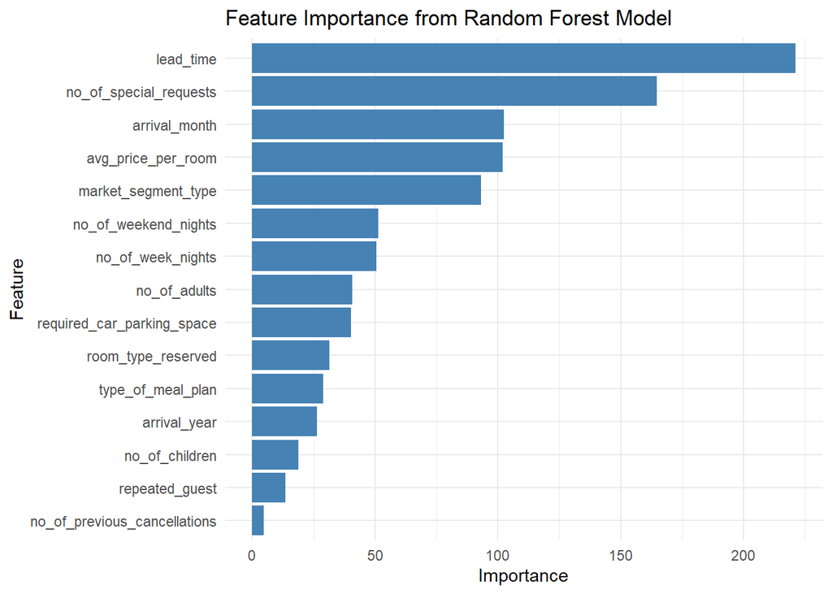

```r
ggplot(importance_df, aes(x = reorder(Feature, Importance), y = Importance)) +
  geom_bar(stat = "identity", fill = "steelblue") +
  coord_flip() +  # Flip the axes to make it easier to read
  labs(title = "Feature Importance from Random Forest Model",
       x = "Feature", y = "Importance") +
  theme_minimal()
```

```r
# Converting booking status to numeric
hotel_data$booking_status_binary <- as.numeric(hotel_data$booking_status_binary)
hotel_data$market_segment_type_num <- as.numeric(hotel_data$market_segment_type)
hotel_data$arrival_month_num <- as.numeric(hotel_data$arrival_month)

corr_data <- hotel_data[, c("booking_status_binary", "lead_time", "no_of_special_requests",
                            "avg_price_per_room", "market_segment_type_num", "no_of_week_nights",
                            "no_of_weekend_nights", "arrival_month_num")]

#correlation matrix
cor_matrix <- cor(corr_data)

print(cor_matrix)
```

```
##                         booking_status_binary lead_time no_of_special_requests
## booking_status_binary                  1.0000   0.43854                -0.2531
## lead_time                              0.4385   1.00000                -0.1016
## no_of_special_requests                -0.2531  -0.10164                 1.0000
## avg_price_per_room                     0.1426  -0.06260                 0.1844
## market_segment_type_num                0.1360  -0.00693                 0.3085
## no_of_week_nights                      0.0930   0.14965                 0.0460
## no_of_weekend_nights                   0.0616   0.04660                 0.0606
## arrival_month_num                     -0.0112   0.13681                 0.1106
##                         avg_price_per_room market_segment_type_num
## booking_status_binary              0.14257                 0.13601
## lead_time                         -0.06260                -0.00693
## no_of_special_requests             0.18438                 0.30848
## avg_price_per_room                 1.00000                 0.37565
## market_segment_type_num            0.37565                 1.00000
## no_of_week_nights                  0.02275                 0.11295
## no_of_weekend_nights              -0.00452                 0.12907
## arrival_month_num                  0.05442                -0.00631
##                         no_of_week_nights no_of_weekend_nights
## booking_status_binary              0.0930              0.06156
## lead_time                          0.1497              0.04660
## no_of_special_requests             0.0460              0.06059
## avg_price_per_room                 0.0228             -0.00452
## market_segment_type_num            0.1130              0.12907
## no_of_week_nights                  1.0000              0.17958
## no_of_weekend_nights               0.1796              1.00000
## arrival_month_num                  0.0374             -0.00989
##                         arrival_month_num
## booking_status_binary            -0.01123
## lead_time                         0.13681
## no_of_special_requests            0.11055
## avg_price_per_room                0.05442
## market_segment_type_num          -0.00631
## no_of_week_nights                 0.03738
## no_of_weekend_nights             -0.00989
## arrival_month_num                 1.00000
```

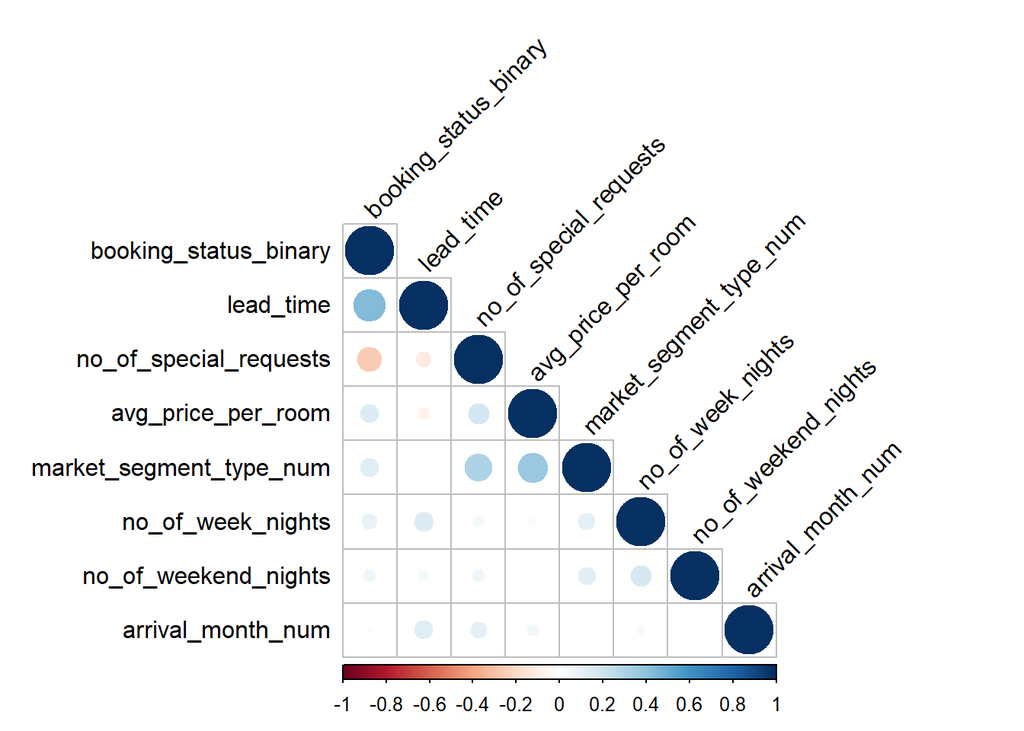

```r
# Plotting the correlation matrix using corrplot
corrplot(cor_matrix, method = "circle", type = "lower", tl.col = "black", tl.srt = 45)
```

## **Building booking cancellation predictive model using the key factors**

### **Checking for multicollinearity**

```r
# Assuming you've already fitted the logistic regression model
lm_model1 <- lm(booking_status_binary ~ lead_time + no_of_special_requests + avg_price_per_room +
                 market_segment_type + no_of_week_nights + no_of_weekend_nights + arrival_month,
                 data = hotel_data)
#summary(lm_model1)

gvif_values <- vif(lm_model1)

print(gvif_values)
```

```
##                        GVIF Df GVIF^(1/(2*Df))
## lead_time              1.25  1            1.12
## no_of_special_requests 1.21  1            1.10
## avg_price_per_room     1.44  1            1.20
## market_segment_type    1.70  4            1.07
## no_of_week_nights      1.08  1            1.04
## no_of_weekend_nights   1.06  1            1.03
## arrival_month          1.36 11            1.01
```

### **Building model using Random Forest**

```r
hotel_data$booking_status_binary <- as.factor(hotel_data$booking_status_binary)

# Fit Random Forest model for classification (binary target)
rf_model2 <- randomForest(booking_status_binary ~ lead_time + no_of_special_requests + avg_price_per_room +
                          market_segment_type + no_of_week_nights + no_of_weekend_nights + arrival_month,
                          data = hotel_data, ntree = 100)

# Print the model summary to ensure it's treated as classification
print(rf_model2)
```

```
##
## Call:
##  randomForest(formula = booking_status_binary ~ lead_time + no_of_special_requests +      avg_price_per_room + market_segment_type + no_of_week_nights +      no_of_weekend_nights + arrival_month, data = hotel_data,      ntree = 100)
##                Type of random forest: classification
##                      Number of trees: 100
## No. of variables tried at each split: 2
##
##         OOB estimate of  error rate: 10.9%
## Confusion matrix:
##       0    1 class.error
## 0 22832 1558      0.0639
## 1  2397 9488      0.2017
```

```r
pred_class_rf <- predict(rf_model2, newdata = hotel_data)

# Confusion Matrix (Make sure both predicted and actual values have the same levels)
conf_matrix_rf <- confusionMatrix(pred_class_rf, hotel_data$booking_status_binary)
conf_matrix_rf
```

```
## Confusion Matrix and Statistics
##
##           Reference
## Prediction     0     1
##          0 23416  1632
##          1   974 10253
##
##                Accuracy : 0.928
##                  95% CI : (0.925, 0.931)
##     No Information Rate : 0.672
##     P-Value [Acc > NIR] : <2e-16
##
##                   Kappa : 0.835
##
##  Mcnemar's Test P-Value : <2e-16
##
##             Sensitivity : 0.960
##             Specificity : 0.863
##          Pos Pred Value : 0.935
##          Neg Pred Value : 0.913
##              Prevalence : 0.672
##          Detection Rate : 0.646
##    Detection Prevalence : 0.691
##       Balanced Accuracy : 0.911
##
##        'Positive' Class : 0
##
```

```r
# Print confusion matrix and the calculated metrics

conf_matrix_df <- as.data.frame(as.table(conf_matrix_rf))
conf_matrix_df
```

```
##   Prediction Reference  Freq
## 1          0         0 23416
## 2          1         0   974
## 3          0         1  1632
## 4          1         1 10253
```

[figure not shown]

```r
colnames(conf_matrix_df) <- c("Actual", "Predicted", "Freq")  # Rename columns for clarity

# Plot confusion matrix as heatmap using ggplot2
ggplot(conf_matrix_df, aes(x = Predicted, y = Actual, fill = Freq)) +
  geom_tile() +
  geom_text(aes(label = Freq), color = "black", size = 6) +
  scale_fill_gradient(low = "white", high = "blue") +
  labs(x = "Predicted", y = "Actual", title = "Confusion Matrix Heatmap") +
  theme_minimal() +
  theme(axis.text.x = element_text(angle = 45, hjust = 1))
```

```r
# Extracting Precision, Recall, and Accuracy from the confusion matrix
precision <- conf_matrix_rf$byClass['Pos Pred Value']
recall <- conf_matrix_rf$byClass['Sensitivity']
accuracy <- conf_matrix_rf$overall['Accuracy']

cat("Precision:", round(precision, 4), "\n")
```

```
## Precision: 0.935
```

```r
cat("Recall:", round(recall, 4), "\n")
```

```
## Recall: 0.96
```

```r
cat("Accuracy:", round(accuracy, 4), "\n")
```

```
## Accuracy: 0.928
```

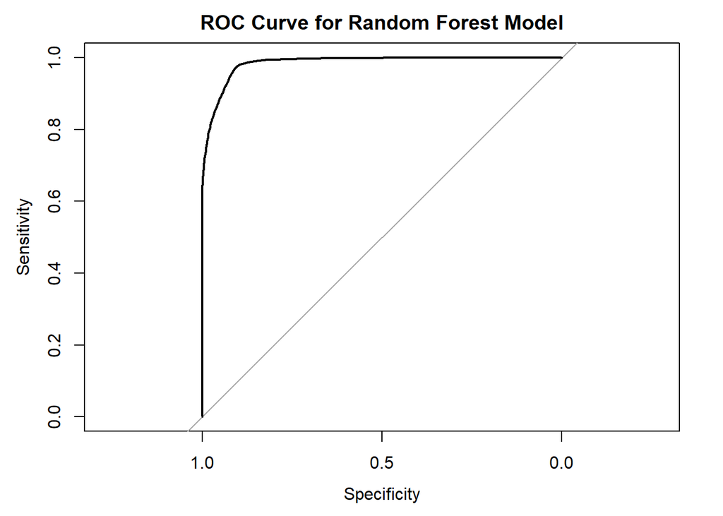

```r
# Predict class probabilities for the binary outcome (probabilities for each class, we need the second column for class 1)
pred_probs_rf <- predict(rf_model2, newdata = hotel_data, type = "prob")[, 2]

# Calculate ROC-AUC for Random Forest (use the second column for class 1 probabilities)
roc_curve_rf <- roc(hotel_data$booking_status_binary, pred_probs_rf)

# Plot the ROC curve
plot(roc_curve_rf, main = "ROC Curve for Random Forest Model")
```

```r
# Print AUC value
auc_value_rf <- auc(roc_curve_rf)
cat("AUC:", round(auc_value_rf, 4), "\n")
```

```
## AUC: 0.985
```

### **Validating the model by cross-validation with Random Forest using 5-fold cross-validation**

```r
# Set up parallel processing (use all but 1 core)
cl <- makeCluster(detectCores() - 1)
registerDoParallel(cl)

# Reduce number of trees for faster cross-validation
ntree_val <- 50

# Perform cross-validation with Random Forest using 5-fold cross-validation
cv_model <- train(booking_status_binary ~ lead_time + no_of_special_requests + avg_price_per_room +
                  market_segment_type + no_of_week_nights + no_of_weekend_nights + arrival_month,
                  data = hotel_data,
                  method = "rf",
                  trControl = trainControl(method = "cv", number = 5),  # 5-fold cross-validation
                  tuneGrid = data.frame(mtry = 3),  # You can adjust mtry for tuning
                  ntree = ntree_val)  # Set ntree to a smaller value for faster computation

# Print the results of cross-validation
print(cv_model)
```

```
## Random Forest
##
## 36275 samples
##     7 predictor
##     2 classes: '0', '1'
##
## No pre-processing
## Resampling: Cross-Validated (5 fold)
## Summary of sample sizes: 29020, 29020, 29020, 29020, 29020
## Resampling results:
##
##   Accuracy  Kappa
##   0.868     0.686
##
## Tuning parameter 'mtry' was held constant at a value of 3
```

```r
# Stop the parallel cluster
stopCluster(cl)
```

# **References**

1. Antonio, N., de Almeida, A., & Nunes, L. (2017). Predicting hotel bookings cancellation with a machine learning classification model. In 2017 IEEE International Conference on Data Mining Workshops (ICDMW) (pp. 1100–1107). IEEE. https://ieeexplore.ieee.org/document/8260781
2. Antonio, N., de Almeida, A., & Nunes, L. (2017). Predicting hotel booking cancellations to decrease uncertainty and increase revenue.Tourism & Management Studies, 13(2), 25–39. https://www.researchgate.net/publication/310504011_Predicting_Hotel_Booking_Cancellation_to_Decrease_Uncertainty_and_Increase_Revenue
3. Abeyrathne, C., & Bandara, H. M. N. D. (2023). Hotel booking cancellation prediction system using machine learning. Faculty of Engineering, University of Ruhuna. https://www.researchgate.net/publication/380515766_Hotel_Booking_Cancellation_Prediction_System_using_Machine_Learning